# Complex Networks 3

Walter Quattrociocchi

- **Graph Visualization**
- **Graph Layouts**
- **Bipartite Visualization**

### Plotting in Igraph

-Plot parameters in igraph

- Plotting with igraph a list of options is included in your handout.
  - node options (starting with 'vertex.')
  - and edge options (starting with 'edge.').
  - use command for more details: ?igraph.plotting

### Plotting in Igraph

- We can set the node & edge options in two ways - one is to specify them in the plot() function, as we are doing below.
- Plot with curved edges (edge.curved=.1) and reduce arrow size:

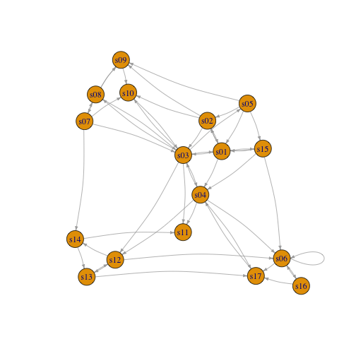

```r
library(igraph)
nodes <- read.csv("Dataset1-Media-Example-NODES.csv", header=T, as.is=T)
links <- read.csv("Dataset1-Media-Example-EDGES.csv", header=T, as.is=T)
net <- graph_from_data_frame(d=links, vertices=nodes, directed=T)
plot(net, edge.arrow.size=.4, edge.curved=.1)
```

### Plotting in Igraph

- Set node color to orange and the border color to hex #555555
- Replace the vertex label with the node names stored in “media”

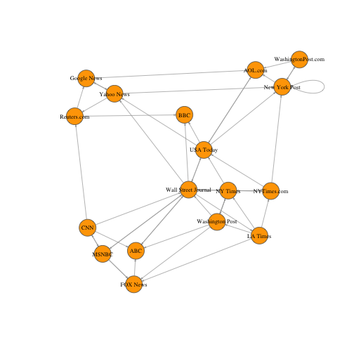

```r
plot(net, edge.arrow.size=.2, edge.curved=0,
     vertex.color="orange", vertex.frame.color="#555555",
     vertex.label=V(net)$media, vertex.label.color="black",
     vertex.label.cex=.7)
```

### Plotting in Igraph

The second way to set attributes is to add them to the igraph object.

- Generate colors based on media type:

```r
colrs <- c("gray50", "tomato", "gold")
V(net)$color <- colrs[V(net)$media.type]
```

- Set node size based on audience size:

```r
V(net)$size <- V(net)$audience.size*0.7
```

- The labels are currently node IDs.
  - Setting them to NA will render no labels:

```r
V(net)$label.color <- "black"
V(net)$label <- NA
```

### Plotting in Igraph

- Set edge width based on weight:

```r
E(net)$width <- E(net)$weight/6
```

- change arrow size and edge color:

```r
E(net)$arrow.size <- .2
E(net)$edge.color <- "gray80"
```

### Plotting in Igraph

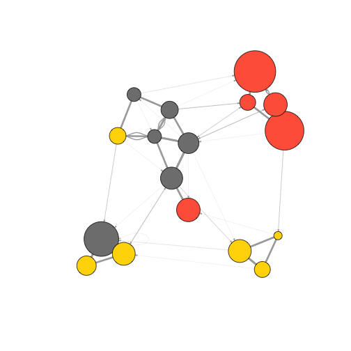

```r
plot(net)
```

### Plotting in Igraph

- We can also override the attributes explicitly in the plot:

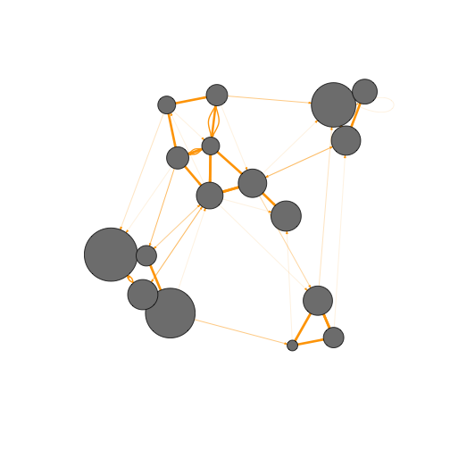

```r
plot(net, edge.color="orange", vertex.color="gray50")
```

### Plotting in Igraph

- We can also add a legend explaining the meaning of the colors we used:

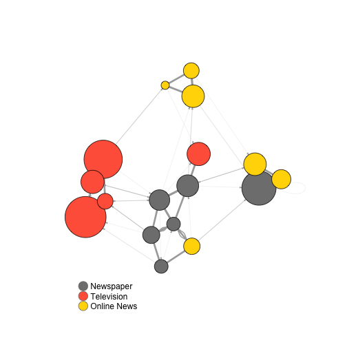

```r
plot(net)
legend(x=-1.1, y=-1.1, c("Newspaper","Television", "Online News"), pch=21,
       col="#777777", pt.bg=colrs, pt.cex=2.5, bty="n", ncol=1)
```

### Plotting in Igraph

- Sometimes, especially with semantic networks, we may be interested in plotting only the labels of the nodes:

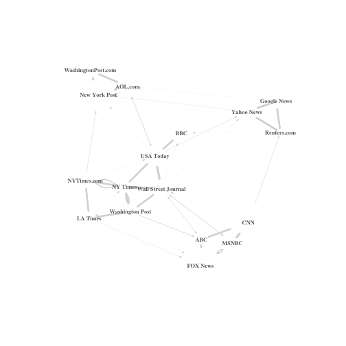

```r
plot(net, vertex.shape="none", vertex.label=V(net)$media,
     vertex.label.font=2, vertex.label.color="gray40",
     vertex.label.cex=.7, edge.color="gray85")
```

### Plotting in Igraph

- Let's color the edges of the graph based on their source node color.
- We'll get the starting node for each edge with “ends()”.

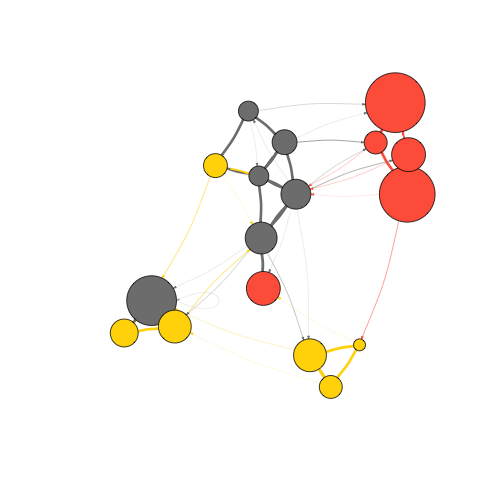

```r
edge.start <- ends(net, es=E(net), names=F)[,1]
edge.col <- V(net)$color[edge.start]
my_layout = layout.fruchterman.reingold(net)
plot(net, edge.color=edge.col, edge.curved=.1, layout = my_layout)
```

### Layouts

Let's generate a slightly larger 80-node graph.

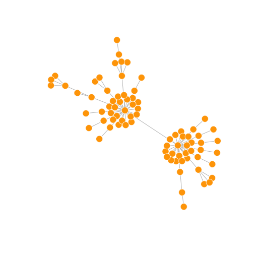

```r
net.bg <- sample_pa(80, 1.2)
V(net.bg)$size <- 8
V(net.bg)$frame.color <- "white"
V(net.bg)$color <- "orange"
V(net.bg)$label <- ""
E(net.bg)$arrow.mode <- 0
plot(net.bg)
```

- Network layouts are algorithms that return coordinates for each node in a network.

### Layouts

- You can set the layout in the plot function:

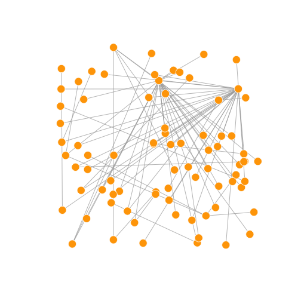

```r
plot(net.bg, layout=layout_randomly)
```

### Layouts

Or calculate the vertex coordinates in advance:

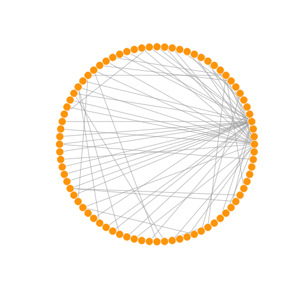

```r
l <- layout_in_circle(net.bg)
plot(net.bg, layout=l)
```

### Layouts

- Randomly placed vertices

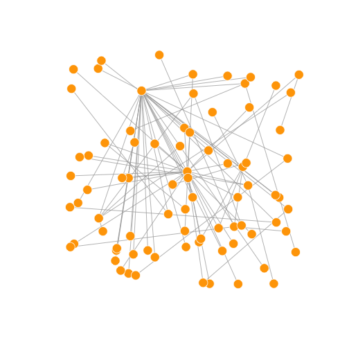

```r
l <- layout_randomly(net.bg)
plot(net.bg, layout=l)
```

### Layouts

- 3D sphere layout

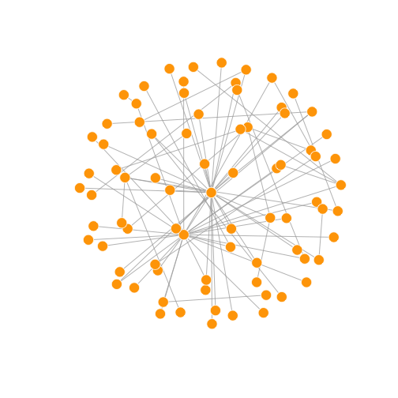

```r
l <- layout_on_sphere(net.bg)
plot(net.bg, layout=l)
```

### Layouts

- The Fruchterman-Reingold force-directed algorithm
- Nice but slow, most often used in graphs smaller than ~1000 vertices.

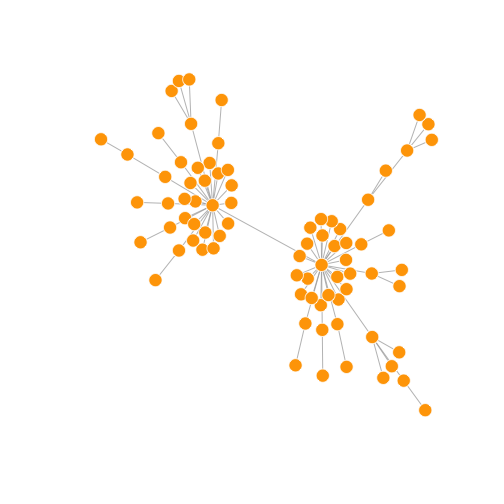

```r
l <- layout_with_fr(net.bg)
plot(net.bg, layout=l)
```

### Layouts

- You will also notice that the layout is not deterministic - different runs
- will result in slightly different configurations. Saving the layout in l
- allows us to get the exact same result multiple times.

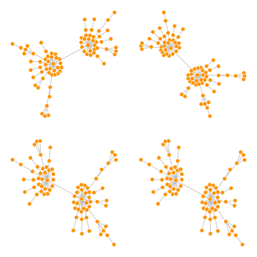

```r
par(mfrow=c(2,2), mar=c(1,1,1,1))
plot(net.bg, layout=layout_with_fr)
plot(net.bg, layout=layout_with_fr)
plot(net.bg, layout=l)
plot(net.bg, layout=l)
```

### Layouts

- By default, the coordinates of the plots are rescaled to the [-1,1] interval for both x and y. You can change that with the parameter “rescale=FALSE” and rescale your plot manually by multiplying the coordinates by a scalar.
- You can use norm_coords to normalize the plot with the boundaries you want.

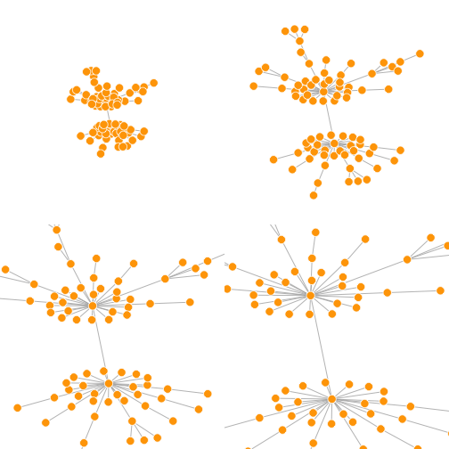

```r
# Get the layout coordinates:
l <- layout_with_fr(net.bg)
# Normalize them so that they are in the -1, 1 interval:
l <- norm_coords(l, ymin=-1, ymax=1, xmin=-1, xmax=1)
par(mfrow=c(2,2), mar=c(0,0,0,0))
plot(net.bg, rescale=F, layout=l*0.4)
plot(net.bg, rescale=F, layout=l*0.8)
plot(net.bg, rescale=F, layout=l*1.2)
plot(net.bg, rescale=F, layout=l*1.6)
```

### Layouts

Another popular force-directed algorithm that produces nice results for connected graphs is Kamada Kawai. Like Fruchterman Reingold, it attempts to minimize the energy in a spring system.

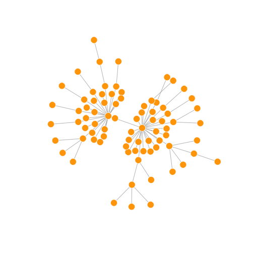

```r
l <- layout_with_kk(net.bg)
plot(net.bg, layout=l)
```

### Layouts

The LGL algorithm is for large connected graphs. Here you can specify a root - the node that will be placed in the middle of the layout.

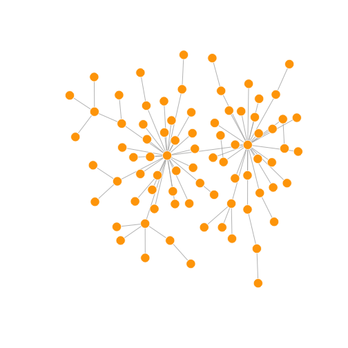

```r
plot(net.bg, layout=layout_with_lgl)
```

### Improving Network Analysis

Notice that this network plot is still not too helpful. We can identify the type and size of nodes, but cannot see much about the structure since the links we're examining are so dense. One way to approach this is to see if we can sparsify the network.

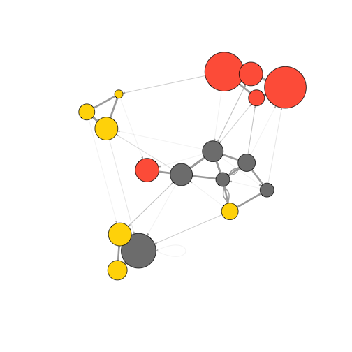

```r
plot(net)
```

### Improving Network Analysis

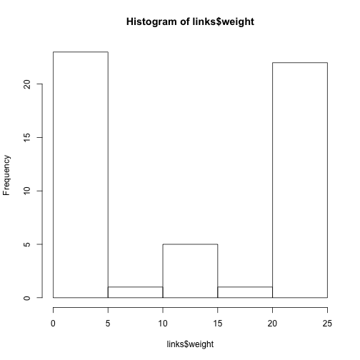

```r
hist(links$weight)
```

```r
mean(links$weight)
```

```
[1] 11.69231
```

```r
sd(links$weight)
```

```
[1] 9.287433
```

### Improving Network Analysis

- There are more sophisticated ways to extract the key edges, but for the purposes of this excercise we'll only keep ones that have weight higher than the mean for the network.
- We can delete edges using delete_edges(net, edges)

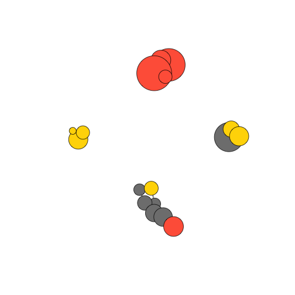

```r
cut.off <- mean(links$weight)
net.sp <- delete_edges(net, E(net)[weight<cut.off])
plot(net.sp)
```

### Improving Network Analysis

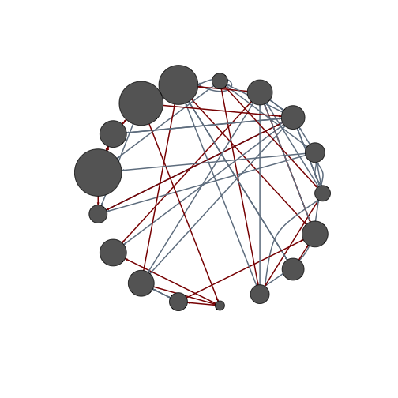

```r
E(net)$width <- 2
plot(net, edge.color=c("dark red", "slategrey")[(E(net)$type=="hyperlink")+1],
      vertex.color="gray40", layout=layout_in_circle)
```

### Improving Network Analysis

Another way to delete edges:

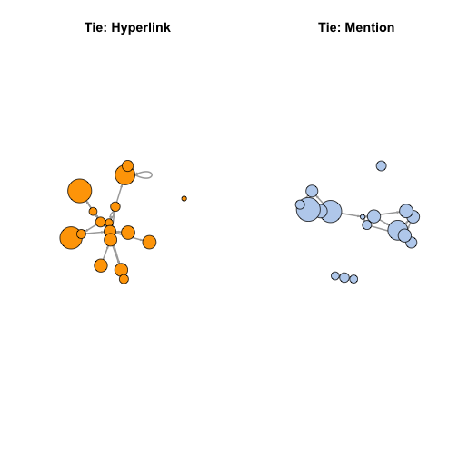

```r
net.m <- net - E(net)[E(net)$type=="hyperlink"]
net.h <- net - E(net)[E(net)$type=="mention"]
par(mfrow=c(1,2))

plot(net.h, vertex.color="orange", main="Tie: Hyperlink")
plot(net.m, vertex.color="lightsteelblue2", main="Tie: Mention")
```

### Improving Network Analysis

Make sure the nodes stay in place in both plots:

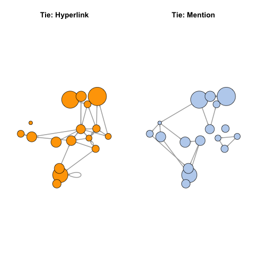

```r
par(mfrow=c(1,2),mar=c(1,1,4,1))
l <- layout_with_fr(net)
plot(net.h, vertex.color="orange", layout=l, main="Tie: Hyperlink")
plot(net.m, vertex.color="lightsteelblue2", layout=l, main="Tie: Mention")
```

### Heatmaps

A quick reminder that there are other ways to represent a network:

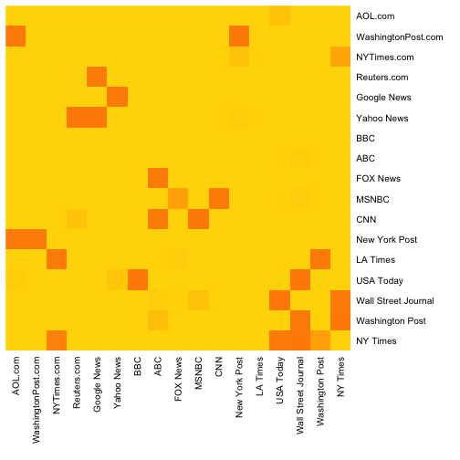

```r
# Heatmap of the network matrix:
netm <- get.adjacency(net, attr="weight", sparse=F)
colnames(netm) <- V(net)$media
rownames(netm) <- V(net)$media

palf <- colorRampPalette(c("gold", "dark orange"))
heatmap(netm[,17:1], Rowv = NA, Colv = NA, col = palf(20),
        scale="none", margins=c(10,10) )
```

### Plotting Bipartite Networks

```r
nodes2 <- read.csv("Dataset2-Media-User-Example-NODES.csv", header=T, as.is=T)
links2 <- read.csv("Dataset2-Media-User-Example-EDGES.csv", header=T, row.names=1)
links2 <- as.matrix(links2)
net2 <- graph_from_incidence_matrix(links2)
head(nodes2)
```

```
   id   media media.type media.name audience.size
1 s01     NYT          1  Newspaper            20
2 s02    WaPo          1  Newspaper            25
3 s03     WSJ          1  Newspaper            30
4 s04    USAT          1  Newspaper            32
5 s05 LATimes          1  Newspaper            20
6 s06     CNN          2         TV            56
```

```r
head(links2)
```

```
    U01 U02 U03 U04 U05 U06 U07 U08 U09 U10 U11 U12 U13 U14 U15 U16 U17
s01   1   1   1   0   0   0   0   0   0   0   0   0   0   0   0   0   0
s02   0   0   0   1   1   0   0   0   0   0   0   0   0   0   0   0   0
s03   0   0   0   0   0   1   1   1   1   0   0   0   0   0   0   0   0
s04   0   0   0   0   0   0   0   0   1   1   1   0   0   0   0   0   0
s05   0   0   0   0   0   0   0   0   0   0   1   1   1   0   0   0   0
s06   0   0   0   0   0   0   0   0   0   0   0   0   1   1   0   0   1
    U18 U19 U20
s01   0   0   0
s02   0   0   1
s03   0   0   0
s04   0   0   0
s05   0   0   0
s06   0   0   0
```

```r
net2
```

```
IGRAPH 3f37098 UN-B 30 31 --
+ attr: type (v/l), name (v/c)
+ edges from 3f37098 (vertex names):
 [1] s01--U01 s01--U02 s01--U03 s02--U04 s02--U05 s02--U20 s03--U06
 [8] s03--U07 s03--U08 s03--U09 s04--U09 s04--U10 s04--U11 s05--U11
[15] s05--U12 s05--U13 s06--U13 s06--U14 s06--U17 s07--U14 s07--U15
[22] s07--U16 s08--U16 s08--U17 s08--U18 s08--U19 s09--U06 s09--U19
[29] s09--U20 s10--U01 s10--U11
```

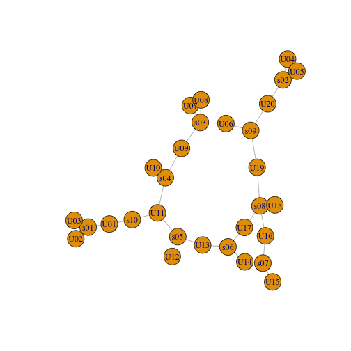

```r
plot(net2)
```

### Plotting Bipartite Networks

```r
net2
```

```
IGRAPH 3f37098 UN-B 30 31 --
+ attr: type (v/l), name (v/c)
+ edges from 3f37098 (vertex names):
 [1] s01--U01 s01--U02 s01--U03 s02--U04 s02--U05 s02--U20 s03--U06
 [8] s03--U07 s03--U08 s03--U09 s04--U09 s04--U10 s04--U11 s05--U11
[15] s05--U12 s05--U13 s06--U13 s06--U14 s06--U17 s07--U14 s07--U15
[22] s07--U16 s08--U16 s08--U17 s08--U18 s08--U19 s09--U06 s09--U19
[29] s09--U20 s10--U01 s10--U11
```

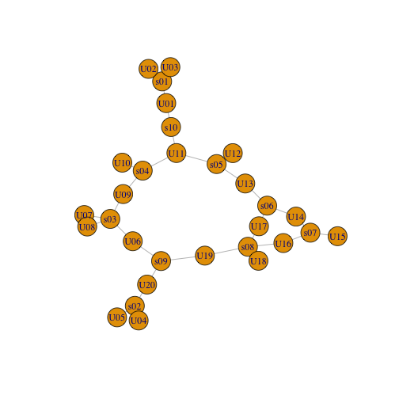

```r
plot(net2)
```

### Plotting Bipartite Networks

This time we will make nodes look different based on their type.

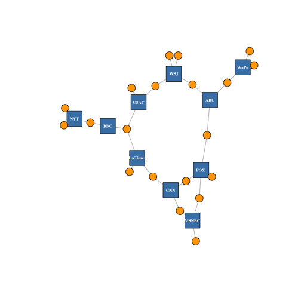

```r
V(net2)$color <- c("steel blue", "orange")[V(net2)$type+1]
V(net2)$shape <- c("square", "circle")[V(net2)$type+1]
V(net2)$label <- ""
V(net2)$label[V(net2)$type==F] <- nodes2$media[V(net2)$type==F]
V(net2)$label.cex=.6
V(net2)$label.font=2
plot(net2, vertex.label.color="white", vertex.size=(2-V(net2)$type)*8)
```

### Plotting Bipartite Networks

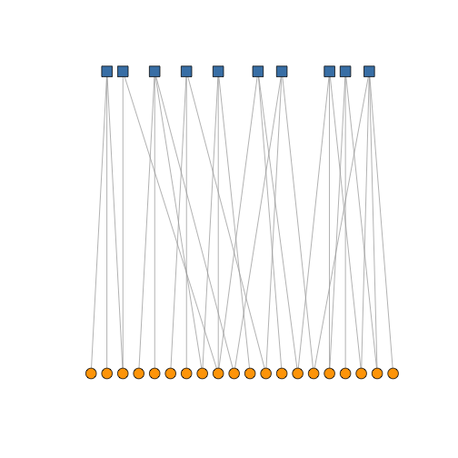

```r
plot(net2, vertex.label=NA, vertex.size=7, layout=layout_as_bipartite)
```

### Plotting Bipartite Networks

Using text as nodes:

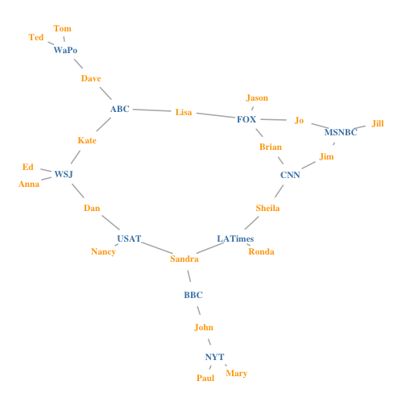

```r
par(mar=c(0,0,0,0))
plot(net2, vertex.shape="none", vertex.label=nodes2$media,
     vertex.label.color=V(net2)$color, vertex.label.font=2,
     vertex.label.cex=.95, edge.color="gray70",  edge.width=2)
```